# Intro_to_R_live_Part1_key

Austin Nuckols

11/3/2020

## Intro to RStudio Editor

Open RStudio and take a look around

You have 4 panes: Source Pane, Console, Environment/History, Files/etc pane

- Console is for experimentation or quick code `(x = 10)`
- Environment/History shows you what objects you have saved in R and what code you have just run, respectively
- Files/etc. shows a lot of things
  - Files shows the files in your current ‘working directory’
    - You may remember directories from the Bash/Linux workshop
    - Your working directory is just the folder that you’re currently in – we’ll talk more about that in a minute
    - *When working in R outside of an R Project (we are in a project right now), you’ll need to be sure that you set your working directory. Otherwise, R will not be able to find any files/data you try to reference*
  - Plots is self-explanatory
  - Packages just shows your package library and the ones that are currently loaded. You can mostly ignore this
  - Help can be used to look up the help page of a function `(help(mean))`
  - Viewer is for some other outputs that aren’t plots
- Source is where scripts (or similar file types) you are working on will go.
- Importantly, what you put in your console should be considered NOT saved, so code that you like should always be put into the script file

You can open a script file in the top left corner by clicking the white sheet with a green plus on it, or by choosing File > New File > R Script. Also, if you want to take notes directly in the editor, I recommend using an R Markdown file which will let you separate code and regular text. When I say “script” in this workshop moving forward, I will be referring to any of these file types

If you want to change any settings, you should go to Tools > Global Options which will open a window where you can customize your theme as well as several other features of RStudio

Any major questions?

## Code

Let’s talk about some code

### Run code

To run code you can press enter in the Console or press Ctrl+Enter (or Cmd+Enter for Mac) when in a script/chunk.

If you are in Rmd right now, choose the Insert option (just above the source pane w/ Green square with a c and a plus) and choose ‘R’ to insert an R chunk. In Rmd this is how code is separated from text

`Shortcut: Ctrl+Alt+I - this inserts a chunk`

```r
4+8
```

```
## [1] 12
```

In script, be sure your cursor is in the code you want to run.

You can also highlight the code and click Run on the top right, but this is slower, so I don’t recommend it

### Comments

If you’re in a script file (like me) you’ll use # to indicate a comment.

In your coding space, type # and say this is a comment and try to run it – it didn’t do anything right?

You can put comments in the same line as actual code as long as it’s after the code, and your code will run while the comment will not

```r
# Comments are not run as code and are great for leaving notes in your code
```

```r
x <- 10
x # Add another comment
```

```
## [1] 10
```

In a chunk, let’s assign a new variable: Ctrl+Alt+I - this inserts a chunk

`Another shortcut that's nice is the assignment shortcut:` `Alt + - (Alt + the minus sign)`

```r
y <- 8 # This is our new object 'y'
```

Questions?

## Practical Data Examples (Part 1)

### Up top items

Now we are going to read in some data. In this tutorial, we are going to use the tidyverse package, the lubridate package, and the here package. If you have not already installed them, please do now using

```r
install.packages("tidyverse", "lubridate", "here", "xlsx")
```

While this installs, I’ll talk about packages. Packages simply put are just a collection of functions that were built for a specific purpose. You get to use the shorthand function, and the file that defines the function in the package actually just contains instructions that R can use on the back end to convert the function into base R commands.

The tidyverse is actually a suite of packages that are meant to simplify R programming and empower the users. We are going to work using functions from within tidyverse packages.

After you’ve installed it (or if it was previously installed), we need to load it using library()

```r
library(tidyverse)
library(here)
```

library() tells R to load the package to the current session so that it can be used. Not all libraries are loaded all of the time because sometimes, their functions conflict with functions in other packages. Therefore, it is necessary to load a library when you want to use it

Now we need to ensure that our working directory is set. The working directory (see the Files pane) is simply where R starts when it needs to look for files/data. Setting your working directory is crucial. This is why we use the ‘here’ package.

In the console, we need to type the following code: `getwd()`

It should say “~/DVAC_Nov_2020_intro_R_and_ggplot” i.e. it should match the output of `here()`

If it does not, run `setwd(here())`

### Mice

Now let’s start with some actual data. I have generated a dataset for a fictitious experiment looking at two different anxiety treatments (A and B) vs a placebo in mice. Disclaimer: I do not work with mice nor do I work in the realm of anxiety, so if my generic interpretations are off, please forgive me!

First let’s load in the data. This data is a Microsoft Excel file (in .xlsx form), so we will need to load the xlsx library. *Note: you need to have a recent version of JAVA installed!* If this proves to be a barrier, then convert the data to .csv format for ease of reading.

```r
library(xlsx)
```

Now, let’s load the data and get a feel for what we’re looking at. Note: if you’re having trouble with an error claiming “Cannot find data/part1/mice.xlsx”, then add `setwd(here())` in front and run the whole chunk. This is a small blip that can occur with .Rmd files

```r
setwd(here())
mice <- read.xlsx(file = "data/part1/mice.xlsx",
          sheetIndex = 1)
```

There’s a few different functions you can use to take a look at the data

```r
head(mice); head(mice, 20)
```

```
##   NA. mouse_id sex weight birthdates treatment_date treatment open_field_time
## 1   1        1   F   6.32 2020-10-13     2020-11-03         B            0.48
## 2   2        2   F  11.88 2020-10-06     2020-10-27   Placebo            0.29
## 3   3        3   F  16.12 2020-10-02     2020-10-23         B            1.07
## 4   4        4   F  15.94 2020-10-01     2020-10-22         A            1.21
## 5   5        5   F  17.19 2020-09-30     2020-10-21   Placebo            0.20
## 6   6        6   F  19.59 2020-09-16     2020-10-07         B            1.25
```

```
##    NA. mouse_id sex weight birthdates treatment_date treatment open_field_time
## 1    1        1   F   6.32 2020-10-13     2020-11-03         B            0.48
## 2    2        2   F  11.88 2020-10-06     2020-10-27   Placebo            0.29
## 3    3        3   F  16.12 2020-10-02     2020-10-23         B            1.07
## 4    4        4   F  15.94 2020-10-01     2020-10-22         A            1.21
## 5    5        5   F  17.19 2020-09-30     2020-10-21   Placebo            0.20
## 6    6        6   F  19.59 2020-09-16     2020-10-07         B            1.25
## 7    7        7   F  17.65 2020-09-12     2020-10-03   Placebo            0.13
## 8    8        8   F  19.94 2020-09-08     2020-09-29         B            1.11
## 9    9        9   F  20.82 2020-09-04     2020-09-25         B            1.20
## 10  10       10   F  19.79 2020-08-29     2020-09-19   Placebo            0.23
## 11  11       11   F  20.43 2020-08-25     2020-09-15         A            0.72
## 12  12       12   F  20.79 2020-08-13     2020-09-03   Placebo            0.54
## 13  13       13   F  21.33 2020-08-06     2020-08-27   Placebo            0.23
## 14  14       14   F  21.54 2020-08-01     2020-08-22         A            0.75
## 15  15       15   F  21.62 2020-08-01     2020-08-22   Placebo            0.21
## 16  16       16   F  22.29 2020-07-17     2020-08-07   Placebo            0.05
## 17  17       17   F  24.60 2020-07-17     2020-08-07         B            0.97
## 18  18       18   F  22.55 2020-07-09     2020-07-30   Placebo            0.47
## 19  19       19   F  25.25 2020-06-30     2020-07-21         B            0.68
## 20  20       20   F  25.59 2020-06-24     2020-07-15         B            1.12
```

```r
view(mice)
mice; print(mice)
```

```
##    NA. mouse_id sex weight birthdates treatment_date treatment open_field_time
## 1    1        1   F   6.32 2020-10-13     2020-11-03         B            0.48
## 2    2        2   F  11.88 2020-10-06     2020-10-27   Placebo            0.29
## 3    3        3   F  16.12 2020-10-02     2020-10-23         B            1.07
## 4    4        4   F  15.94 2020-10-01     2020-10-22         A            1.21
## 5    5        5   F  17.19 2020-09-30     2020-10-21   Placebo            0.20
## 6    6        6   F  19.59 2020-09-16     2020-10-07         B            1.25
## 7    7        7   F  17.65 2020-09-12     2020-10-03   Placebo            0.13
## 8    8        8   F  19.94 2020-09-08     2020-09-29         B            1.11
## 9    9        9   F  20.82 2020-09-04     2020-09-25         B            1.20
## 10  10       10   F  19.79 2020-08-29     2020-09-19   Placebo            0.23
## 11  11       11   F  20.43 2020-08-25     2020-09-15         A            0.72
## 12  12       12   F  20.79 2020-08-13     2020-09-03   Placebo            0.54
## 13  13       13   F  21.33 2020-08-06     2020-08-27   Placebo            0.23
## 14  14       14   F  21.54 2020-08-01     2020-08-22         A            0.75
```

[output cut: 46 more lines]

```
##    NA. mouse_id sex weight birthdates treatment_date treatment open_field_time
## 1    1        1   F   6.32 2020-10-13     2020-11-03         B            0.48
## 2    2        2   F  11.88 2020-10-06     2020-10-27   Placebo            0.29
## 3    3        3   F  16.12 2020-10-02     2020-10-23         B            1.07
## 4    4        4   F  15.94 2020-10-01     2020-10-22         A            1.21
## 5    5        5   F  17.19 2020-09-30     2020-10-21   Placebo            0.20
## 6    6        6   F  19.59 2020-09-16     2020-10-07         B            1.25
## 7    7        7   F  17.65 2020-09-12     2020-10-03   Placebo            0.13
## 8    8        8   F  19.94 2020-09-08     2020-09-29         B            1.11
## 9    9        9   F  20.82 2020-09-04     2020-09-25         B            1.20
## 10  10       10   F  19.79 2020-08-29     2020-09-19   Placebo            0.23
## 11  11       11   F  20.43 2020-08-25     2020-09-15         A            0.72
## 12  12       12   F  20.79 2020-08-13     2020-09-03   Placebo            0.54
## 13  13       13   F  21.33 2020-08-06     2020-08-27   Placebo            0.23
## 14  14       14   F  21.54 2020-08-01     2020-08-22         A            0.75
```

[output cut: 46 more lines]

```r
str(mice)
```

```
## 'data.frame':    60 obs. of  8 variables:
##  $ NA.            : chr  "1" "2" "3" "4" ...
##  $ mouse_id       : chr  "1" "2" "3" "4" ...
##  $ sex            : chr  "F" "F" "F" "F" ...
##  $ weight         : num  6.32 11.88 16.12 15.94 17.19 ...
##  $ birthdates     : Date, format: "2020-10-13" "2020-10-06" ...
##  $ treatment_date : Date, format: "2020-11-03" "2020-10-27" ...
##  $ treatment      : chr  "B" "Placebo" "B" "A" ...
##  $ open_field_time: num  0.48 0.29 1.07 1.21 0.2 1.25 0.13 1.11 1.2 0.23 ...
```

```r
summary(mice)
```

```
##      NA.              mouse_id             sex                weight
##  Length:60          Length:60          Length:60          Min.   : 6.32
##  Class :character   Class :character   Class :character   1st Qu.:21.60
##  Mode  :character   Mode  :character   Mode  :character   Median :25.79
##                                                           Mean   :26.28
##                                                           3rd Qu.:31.28
##                                                           Max.   :38.98
##    birthdates         treatment_date        treatment         open_field_time
##  Min.   :2020-04-22   Min.   :2020-05-13   Length:60          Min.   :0.0500
##  1st Qu.:2020-06-08   1st Qu.:2020-06-29   Class :character   1st Qu.:0.3475
##  Median :2020-07-19   Median :2020-08-09   Mode  :character   Median :0.8000
##  Mean   :2020-07-23   Mean   :2020-08-13                      Mean   :0.7435
##  3rd Qu.:2020-09-12   3rd Qu.:2020-10-03                      3rd Qu.:1.0725
##  Max.   :2020-10-13   Max.   :2020-11-03                      Max.   :1.7100
```

We see that there are a couple of grouping variables like treatment and sex, and index variable (mouse_id), dates, weight, and then our primary dependent variable of interest: open_field_time

Importantly, we see that this data could be cleaned a bit to make it more useful. For example, the NA. column appears to be an artifact from when I created and saved the mice data (oops). Additionally, sex and treatment are factors. These are essentially a data type that R knows you will likely use as a grouping variable. We can change these variables into factors easily.

Additionally, let’s say that our mouse tech got back to us and told us that some of the mice had some leg injuries meaning that their weight and behavior scores are affected – we should remove these observations

Let’s make these changes

Pipe operator can be read as “and then”. It is used to take the output of one operation and use it as the input for the next

%>% Shortcut: Ctrl+Shift+M

```r
injured <- c(4, 26, 51) #define the mice_ids of the injured mice

mice_clean <- mice %>%
  select(-NA.) %>%                            #Select allows you to choose which variables to keep or remove (remove variables by putting the - sign in front)
  mutate(sex = as.factor(sex),                #Mutate creates another variable for the data.frame. This can be a re-factoring of an existing variable or a completely new variable
         treatment = as.factor(treatment)) %>%
  filter(!mouse_id %in% injured)             #Filter allows you to define observations (rows) to keep or remove based on logical criteria. Here, the "!" translates to "not" as in "mouse_ids NOT in injured". Note: filter() can take any logical criteria. E.g. filter(mice, weight > 20) would work just fine

#Now look at the output for summary()

summary(mice_clean)
```

```
##    mouse_id         sex        weight        birthdates
##  Length:57          F:24   Min.   : 6.32   Min.   :2020-04-22
##  Class :character   M:33   1st Qu.:21.62   1st Qu.:2020-06-08
##  Mode  :character          Median :25.59   Median :2020-07-21
##                            Mean   :26.22   Mean   :2020-07-24
##                            3rd Qu.:31.22   3rd Qu.:2020-09-12
##                            Max.   :38.98   Max.   :2020-10-13
##  treatment_date         treatment  open_field_time
##  Min.   :2020-05-13   A      :18   Min.   :0.0500
##  1st Qu.:2020-06-29   B      :19   1st Qu.:0.3100
##  Median :2020-08-11   Placebo:20   Median :0.7700
##  Mean   :2020-08-14                Mean   :0.7254
##  3rd Qu.:2020-10-03                3rd Qu.:1.0600
##  Max.   :2020-11-03                Max.   :1.7100
```

```r
#Now we have a nice count for exactly how many of each we have.
```

Notice that I am giving a descriptive name to the mice object after I make the modifications that I want to make. Instead of mice2 or mice3, I’m using mice_clean since I have done all of my cleaning operations in one shot. The other thing to notice is that I’m using snake case. This is the use of underscores to separate words. There are other methods like CamelCase or using dot.case. CamelCase is fine, but I would recommend against dot case because many programming languages use “.” to separate an object and the method used on it (if you’re familiar with Python or Javascript, then you’ve definitely seen this). Overall, CamelCase or snake_case are the best to use. I will use snake case.

**The grand takeaways are 1) use a naming strategy that does not reinforce bad habits or conflict with other languages you may use (ie use CamelCase or snake_case) and 2) use descriptive terms when naming your objects. This will be incredibly useful when you have to revisit old code**

Great, so let’s get to the good stuff

In our hypothetical example, we are starting treatment with 1 of 3 treatment options 3 weeks after our mices’ births. We can actually check that in the code:

```r
mice_clean %>%
  mutate(time_to_treatment = treatment_date - birthdates) #Here we used mutate to make a variable out of existing variables
```

```
##    mouse_id sex weight birthdates treatment_date treatment open_field_time
## 1         1   F   6.32 2020-10-13     2020-11-03         B            0.48
## 2         2   F  11.88 2020-10-06     2020-10-27   Placebo            0.29
## 3         3   F  16.12 2020-10-02     2020-10-23         B            1.07
## 4         5   F  17.19 2020-09-30     2020-10-21   Placebo            0.20
## 5         6   F  19.59 2020-09-16     2020-10-07         B            1.25
## 6         7   F  17.65 2020-09-12     2020-10-03   Placebo            0.13
## 7         8   F  19.94 2020-09-08     2020-09-29         B            1.11
## 8         9   F  20.82 2020-09-04     2020-09-25         B            1.20
## 9        10   F  19.79 2020-08-29     2020-09-19   Placebo            0.23
## 10       11   F  20.43 2020-08-25     2020-09-15         A            0.72
## 11       12   F  20.79 2020-08-13     2020-09-03   Placebo            0.54
## 12       13   F  21.33 2020-08-06     2020-08-27   Placebo            0.23
## 13       14   F  21.54 2020-08-01     2020-08-22         A            0.75
## 14       15   F  21.62 2020-08-01     2020-08-22   Placebo            0.21
```

[output cut: 101 more lines]

So we see that our mice begin treatment at 3 weeks

Now, let’s say there are a few outputs we care about. We want to see which of our treatments reduces the anxiety levels in our mice. This is measured by the open field test. Simply put, mice don’t want to be in the center of an open field because it exposes them to potential predators. Some anxiolytic drugs (or anxiety-reducing drugs) can increase a mouse’s time spent in the center, supporting the paradigm for testing anxiety in mice (Choleris et al. 2001). We have collected data on the cumulative time a mouse spent in the center (using a camera with tracking software) – this is stored in “open_field_time” and with the units of minutes

We are also interested in the effect of the treatments on weight. We have some preliminary data suggesting that our anxious little mice aren’t eating appropriately, and these anxiolytic treatments may help induce them to eat more

Let’s start by making some summaries of weight

```r
mice_clean %>% summary() #This gives us a cursory view of our variables, but does not show them by their grouping
```

```
##    mouse_id         sex        weight        birthdates
##  Length:57          F:24   Min.   : 6.32   Min.   :2020-04-22
##  Class :character   M:33   1st Qu.:21.62   1st Qu.:2020-06-08
##  Mode  :character          Median :25.59   Median :2020-07-21
##                            Mean   :26.22   Mean   :2020-07-24
##                            3rd Qu.:31.22   3rd Qu.:2020-09-12
##                            Max.   :38.98   Max.   :2020-10-13
##  treatment_date         treatment  open_field_time
##  Min.   :2020-05-13   A      :18   Min.   :0.0500
##  1st Qu.:2020-06-29   B      :19   1st Qu.:0.3100
##  Median :2020-08-11   Placebo:20   Median :0.7700
##  Mean   :2020-08-14                Mean   :0.7254
##  3rd Qu.:2020-10-03                3rd Qu.:1.0600
##  Max.   :2020-11-03                Max.   :1.7100
```

```r
mice_clean %>%
  group_by(sex) %>% #Group_by allows you to choose some grouping variable off of which summarise()'s or mutate()'s will be done with respect to the grouping variable
  summarise(ave = mean(weight),
            sd = sd(weight),
            range = max(weight) - min(weight))
```

```
## # A tibble: 2 x 4
##   sex     ave    sd range
##   <fct> <dbl> <dbl> <dbl>
## 1 F      21.0  4.77  20.3
## 2 M      30.0  4.96  22.2
```

Great! This is to be expected since male mice tend to be larger than female mice

Let’s check and see if it differs by treatment

```r
mice_clean %>%
  group_by(treatment) %>%
  summarise(ave = mean(weight),
            sd = sd(weight),
            med = median(weight))
```

```
## # A tibble: 3 x 4
##   treatment   ave    sd   med
##   <fct>     <dbl> <dbl> <dbl>
## 1 A          27.8  5.45  27.9
## 2 B          26.1  7.87  25.6
## 3 Placebo    24.9  6.25  24.0
```

```r
#Hmm, it looks like there may not be much of a difference. However, we know that sex is also a variable that plays a role in this

# Let's group by both

mice_clean %>%
  group_by(treatment, sex) %>%
  summarise(ave = mean(weight),
            sd = sd(weight),
            med = median(weight)) %>%  #This is kind of hard to read, so let's add and arrange() argument
  arrange(sex, treatment)
```

```
## # A tibble: 6 x 5
## # Groups:   treatment [3]
##   treatment sex     ave    sd   med
##   <fct>     <fct> <dbl> <dbl> <dbl>
## 1 A         F      22.1  1.98  21.5
## 2 B         F      21.0  6.21  22.7
## 3 Placebo   F      20.6  4.03  21.3
## 4 A         M      29.0  5.19  29.0
## 5 B         M      31.8  5.25  32.7
## 6 Placebo   M      30.0  4.23  29.3
```

However, there’s another variable that we are clearly missing – age

```r
mice_clean %>%
  arrange(desc(birthdates))
```

```
##    mouse_id sex weight birthdates treatment_date treatment open_field_time
## 1         1   F   6.32 2020-10-13     2020-11-03         B            0.48
## 2        28   M  16.83 2020-10-13     2020-11-03         A            0.77
## 3         2   F  11.88 2020-10-06     2020-10-27   Placebo            0.29
## 4        29   M  24.31 2020-10-06     2020-10-27         B            1.32
## 5        30   M  25.37 2020-10-06     2020-10-27         B            1.22
## 6         3   F  16.12 2020-10-02     2020-10-23         B            1.07
## 7        31   M  23.48 2020-10-01     2020-10-22   Placebo            0.30
## 8         5   F  17.19 2020-09-30     2020-10-21   Placebo            0.20
## 9        32   M  24.25 2020-09-30     2020-10-21         A            0.57
## 10       33   M  24.56 2020-09-18     2020-10-09   Placebo            0.42
## 11        6   F  19.59 2020-09-16     2020-10-07         B            1.25
## 12       34   M  26.96 2020-09-16     2020-10-07         B            0.77
## 13        7   F  17.65 2020-09-12     2020-10-03   Placebo            0.13
## 14       35   M  24.94 2020-09-12     2020-10-03         A            0.96
```

[output cut: 43 more lines]

But this is not something you could really group_by() because it’s a continuous variable. The best way that we would do this is actually using a graph to summarize this information. Let’s get to making our first graph.

On ggplot: The “gg” stands for Grammar of Graphics (https://vita.had.co.nz/papers/layered-grammar.html)

In short, the grammar of graphics states that graphs are generated layer by layer, with elements being stacked on top of one another.

Let’s start with plotting the change in weight with the change in age

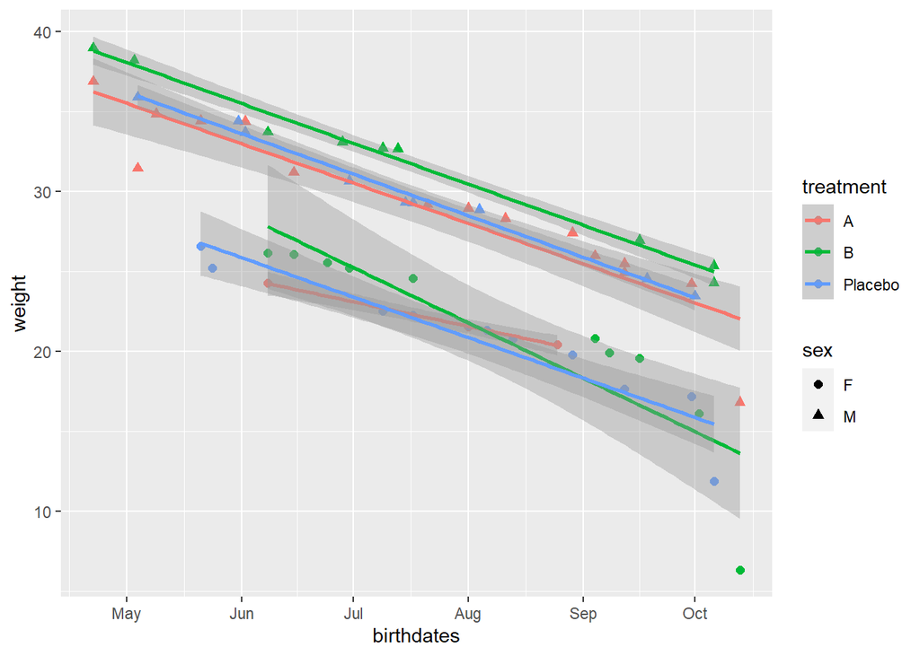

```r
#Let's start by making the base layer
ggplot(data = mice_clean,
       aes(x = birthdates,
           y = weight,
           shape = sex,
           color = treatment))+ #aes() stands for the "aesthetic" layer. It contains specifications of what data will be on what axes
  geom_point(size = 2)+
  geom_smooth(method = "lm",
              formula = "y ~ x") #This stands for linear model
```

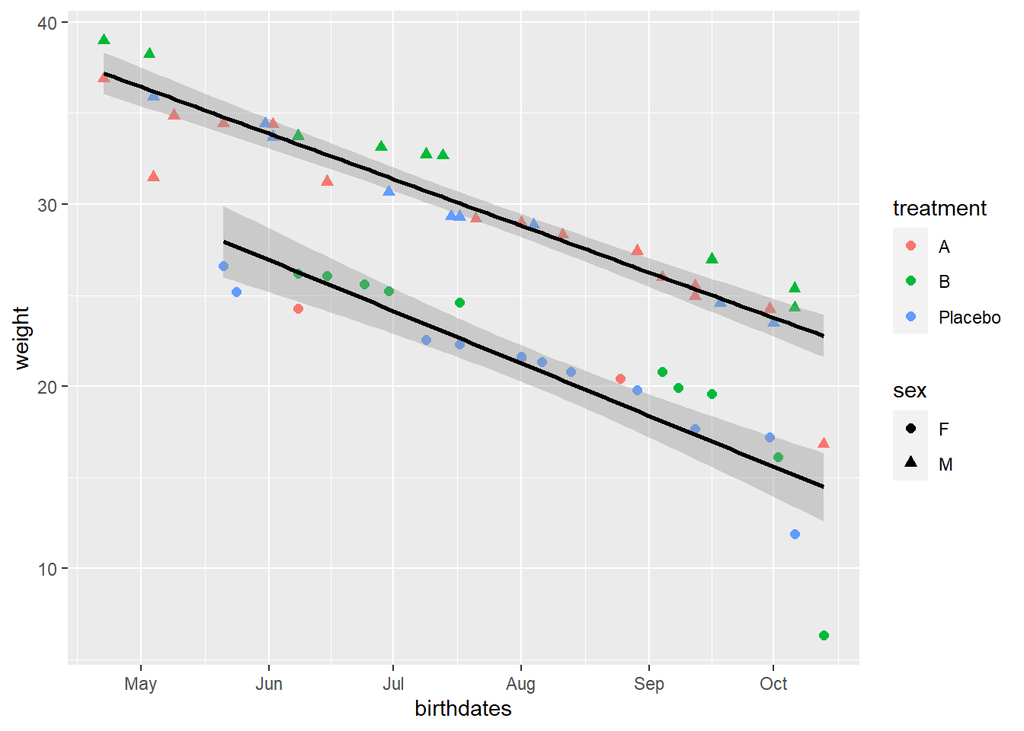

```r
#Cool! We see that males are heavier than females, and the treatments mostly overlap although treatment B seems to be marginally higher in the males. Let's say we want to simplify some of these lines though

ggplot(data = mice_clean,
       aes(x = birthdates,
           y = weight,
           shape = sex))+ #aes() stands for the "aesthetic" layer. It contains specifications of what data will be on what axes
  geom_point(size = 2,
             aes(color = treatment))+
  geom_smooth(method = "lm",
              formula = "y ~ x",
              color = "black")
```

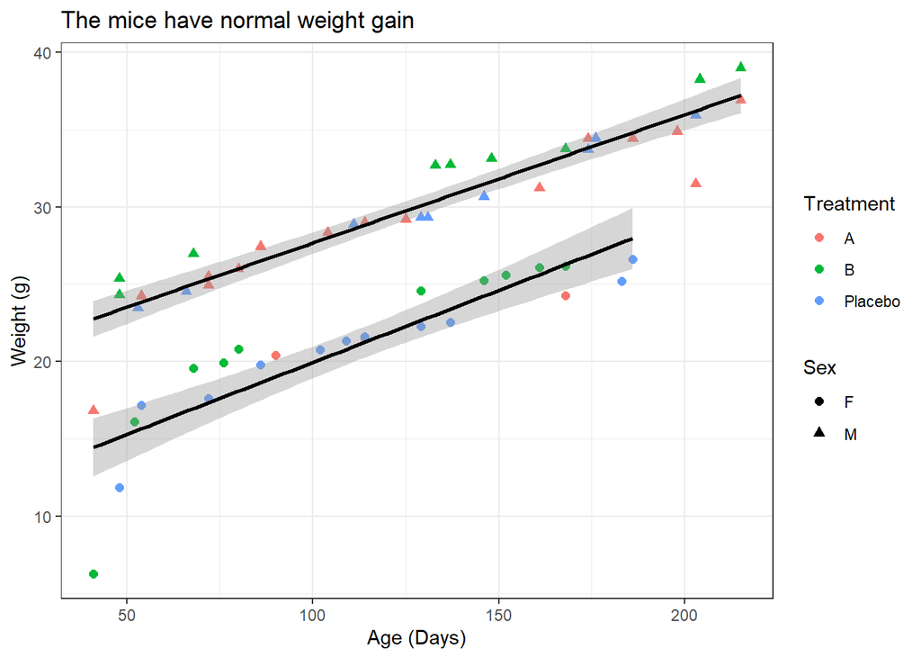

```r
#Let's take their birthdates and mutate age from them

mice_clean %>%
  mutate(age = Sys.Date() - birthdates) %>%  #Yes, we can pipe right into ggplot!
  ggplot(data = ., # data = . just indicates that our previous output (the data frame after the mutate) is the data for our plot. That's what the "." 'pronoun' means
         aes(x = age,
             y = weight,
             shape = sex))+
  geom_point(size = 2,
             aes(color = treatment))+
  geom_smooth(method = "lm",
              formula = "y ~ x",
              color = "black")+
  theme_bw()+
  labs(x = "Age (Days)",
       y = "Weight (g)",
       shape = "Sex",
       color = "Treatment",
       title = "The mice have normal weight gain")
```

Let’s look at our behavior data

First, let’s mutate it out of minutes and into seconds

```r
mice_clean %>%
  mutate(open_field_time = open_field_time*60) %>%
  group_by(
    #sex
    treatment
    ) %>%
  summarise(ave = mean(open_field_time),
            sd = sd(open_field_time))
```

```
## # A tibble: 3 x 3
##   treatment   ave    sd
##   <fct>     <dbl> <dbl>
## 1 A          53.0 15.5
## 2 B          63.2 12.6
## 3 Placebo    16.3  7.82
```

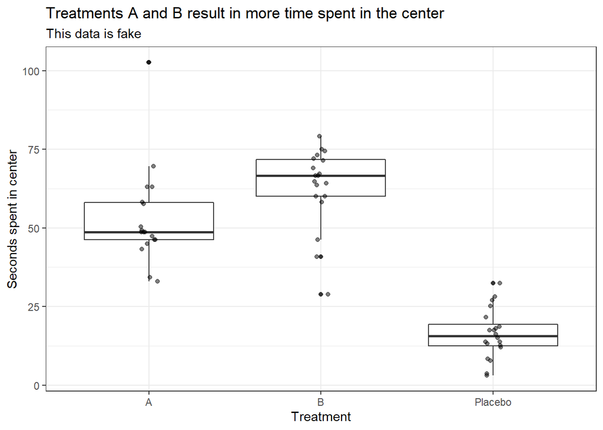

```r
#Wow that's robust! Let's plot this

theme_set(theme_bw())

ggplot(mice_clean,
       aes(x = treatment,
           y = open_field_time*60))+
  #geom_point()+ #this is good, but there's a better way to summarize this

  geom_boxplot()+ #Good, but notice how the boxplot covers the points? How do we fix that?

  # geom_bar(stat = "summary",
  #          fun.y = "mean",
  #          fill = "red",
  #          alpha = 0.3)+ # You have to define stat = "identity" because it defaults to stat = "count" and thinks that you want a histogram
  #
  # stat_summary(geom =
  #                #"errorbar"
  #                "linerange"
  #                ,
  #              fun.data = 'mean_sdl',
  #              fun.args = list(mult = 1),
  #              width = 0.25)+

  #geom_point()+ #By putting the point layer after the boxplot layer, ggplot stacks it on top. Remember, the grammar of graphics dictates plots are built in layers

  #Now what if we want to have the points more spread and not so vertically stacked?

  #geom_jitter() takes your data and adds a tiny amount of random variance just to spread points out for graphing
  geom_jitter(width = 0.05, #Let's keep them mostly tight
              height = 0,   # Let's prevent them from changing their vertical position (so that they better reflect what the median or average times are)
              alpha = 0.5)+ # Let's make them stand out a bit less
  labs(y = "Seconds spent in center",
       x = "Treatment",
       title = "Treatments A and B result in more time spent in the center",
       subtitle = "This data is fake")
```

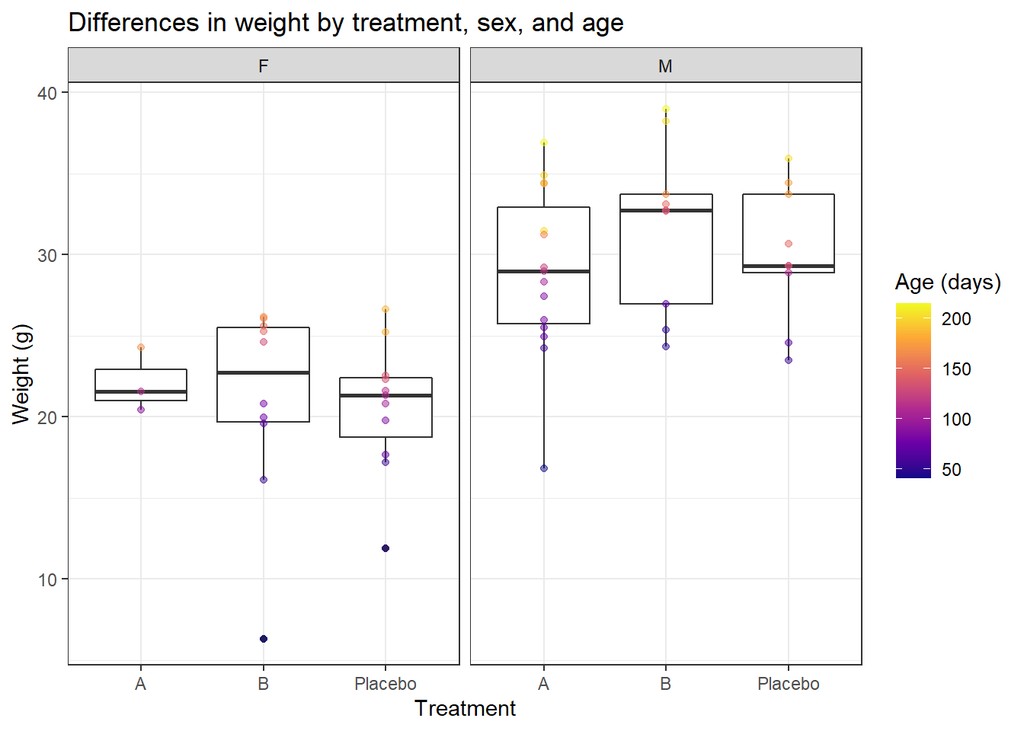

```r
ggsave(filename = "../results/mice_treatment_plot.png")
ggplot(mice_clean %>%
         mutate(age = as.numeric(Sys.Date() - birthdates)),
       aes(x = treatment,
           y = weight,
           #color = sex
           ))+
  geom_boxplot()+
  geom_point(alpha = 0.5,
             aes(color = age))+
  facet_wrap(facets = ~sex)+
  scale_color_viridis_c(option = "C")+
  labs(y = "Weight (g)",
       x = "Treatment",
       color = "Age (days)",
       title = "Differences in weight by treatment, sex, and age")
```

### HEK WB Data

Let’s say I have some WB quantification data for different HEK cell samples. However, I have two data files, one more updated than the other, and I want to clean the first one and then join it together with the more updated one and save it as a new file

Here we are reading the data which is saved in the data/part1/ folder as a .csv file

```r
setwd(here())
hek1 <- read_csv("data/part1/10.23.19_hek.csv")
hek2 <- read_csv("data/part1/hek_wb_combined.csv")
```

Let’s go over some functions you can use to take a peek at your data

```r
head(hek1); head(hek2)
```

```
## # A tibble: 6 x 6
##   sampleid lysis blotid protein value    tp
##   <chr>    <chr> <chr>  <chr>   <dbl> <dbl>
## 1 A        old   a2     lamp2   0.607  1290
## 2 B        old   a2     lamp2   0.674  1380
## 3 A        new   a2     lamp2   0.236   984
## 4 B        new   a2     lamp2   0.209  1060
## 5 A        old   b1     hexa    0.324   914
## 6 B        old   b1     hexa    0.331   954
```

```
## # A tibble: 6 x 5
##   date       sampleid protein  value total_protein_signal
##   <date>     <chr>    <chr>    <dbl>                <dbl>
## 1 2019-10-30 A        lamp2   0.0597                  916
## 2 2019-10-30 B        lamp2   0.0507                  912
## 3 2019-10-30 C        lamp2   0.0425                  994
## 4 2019-10-30 D        lamp2   0.0419                 1070
## 5 2019-10-30 A        hexa    0.342                   916
## 6 2019-10-30 B        hexa    0.318                   912
```

```r
view(hek1)
view(hek2)

summary(hek1)
```

```
##    sampleid            lysis              blotid            protein
##  Length:16          Length:16          Length:16          Length:16
##  Class :character   Class :character   Class :character   Class :character
##  Mode  :character   Mode  :character   Mode  :character   Mode  :character
##
##
##
##      value              tp
##  Min.   :0.1300   Min.   : 768.0
##  1st Qu.:0.3020   1st Qu.: 780.2
##  Median :0.7175   Median : 969.0
##  Mean   :1.0613   Mean   : 956.6
##  3rd Qu.:1.8075   3rd Qu.:1020.0
##  Max.   :3.0000   Max.   :1380.0
```

```r
summary(hek2)
```

```
##       date              sampleid           protein              value
##  Min.   :2019-10-30   Length:32          Length:32          Min.   :0.0419
##  1st Qu.:2019-10-30   Class :character   Class :character   1st Qu.:0.2460
##  Median :2019-11-02   Mode  :character   Mode  :character   Median :0.7325
##  Mean   :2019-11-02                                         Mean   :0.9445
##  3rd Qu.:2019-11-05                                         3rd Qu.:1.1282
##  Max.   :2019-11-05                                         Max.   :3.2000
##  total_protein_signal
##  Min.   : 571.0
##  1st Qu.: 579.8
##  Median : 759.5
##  Mean   : 778.2
##  3rd Qu.: 958.5
##  Max.   :1070.0
```

Now let’s clean this data – we’re going to use a series of functions that are all “piped” together so that the output of one is the input of the next

Summary: Filter for new lysis methods remove variables that aren’t useful rename a variable so that it matches the other data set add a date variable

Join the data Make corrected value by dividing the value by the total protein signal drop the unused variables

Draw up a summary table that I can view

```r
library(lubridate)
hek1_clean <- hek1 %>%
  filter(lysis == "new") %>%
  select(-c(lysis, blotid)) %>%
  rename(total_protein_signal = tp) %>%
  mutate(date = mdy("10-23-19"))

hek_combined_clean <- full_join(hek1_clean, hek2) %>%
  mutate(value_corrected = value/total_protein_signal) %>%
  select(-c(value, total_protein_signal))
hek_combined_clean %>%
  group_by(sampleid, protein) %>%
  summarise(ave = mean(value_corrected),
            med = median(value_corrected),
            sd = sd(value_corrected),
            range = max(value_corrected) - min(value_corrected),
            count = n()) %>%
  arrange(protein)
```

```
## # A tibble: 16 x 7
## # Groups:   sampleid [4]
##    sampleid protein       ave      med        sd     range count
##    <chr>    <chr>       <dbl>    <dbl>     <dbl>     <dbl> <int>
##  1 A        ctsd.im  0.00218  0.00263  0.00137   0.00262       3
##  2 B        ctsd.im  0.00213  0.00225  0.00130   0.00258       3
##  3 C        ctsd.im  0.00187  0.00187  0.00162   0.00229       2
##  4 D        ctsd.im  0.00223  0.00223  0.00201   0.00284       2
##  5 A        ctsd.mat 0.00260  0.00191  0.00224   0.00432       3
##  6 B        ctsd.mat 0.00202  0.00105  0.00187   0.00334       3
##  7 C        ctsd.mat 0.00285  0.00285  0.00289   0.00409       2
##  8 D        ctsd.mat 0.00303  0.00303  0.00319   0.00452       2
##  9 A        hexa     0.000256 0.000214 0.000104  0.000194      3
## 10 B        hexa     0.000245 0.000231 0.0000970 0.000192      3
## 11 C        hexa     0.000257 0.000257 0.0000409 0.0000579     2
## 12 D        hexa     0.000245 0.000245 0.0000592 0.0000838     2
## 13 A        lamp2    0.000607 0.000240 0.000793  0.00145       3
## 14 B        lamp2    0.000571 0.000197 0.000774  0.00141       3
## 15 C        lamp2    0.000646 0.000646 0.000853  0.00121       2
## 16 D        lamp2    0.000459 0.000459 0.000593  0.000839      2
```

Now let’s experiment with different ways of graphing this data using ggplot

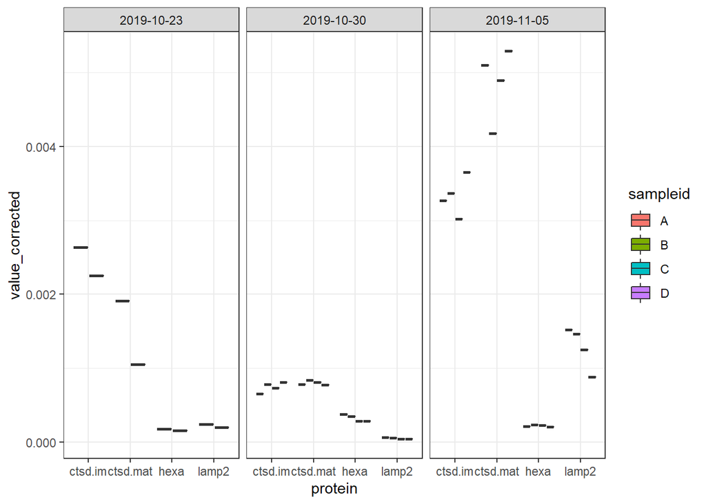

```r
hek_combined_clean %>%
  ggplot(aes(x = protein, y = value_corrected, fill = sampleid))+
  geom_boxplot()+
  facet_wrap(facets = ~date)
```

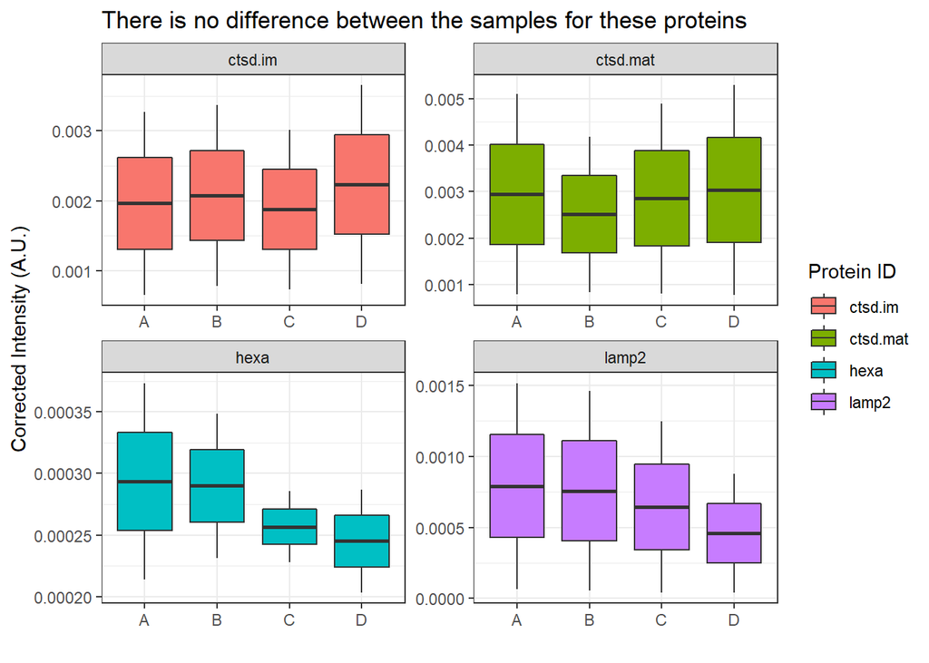

```r
  #geom_point()

hek_combined_clean %>%
  filter(date > mdy("10-23-2019")) %>%
  ggplot(aes(x = sampleid, y = value_corrected, fill = protein))+
  geom_boxplot()+
  facet_wrap(~protein,
             scales = "free")+
  xlab("")+
  ylab("Corrected Intensity (A.U.)")+
  ggtitle("There is no difference between the samples for these proteins")+
  labs(fill = "Protein ID")+
  theme_bw()
```

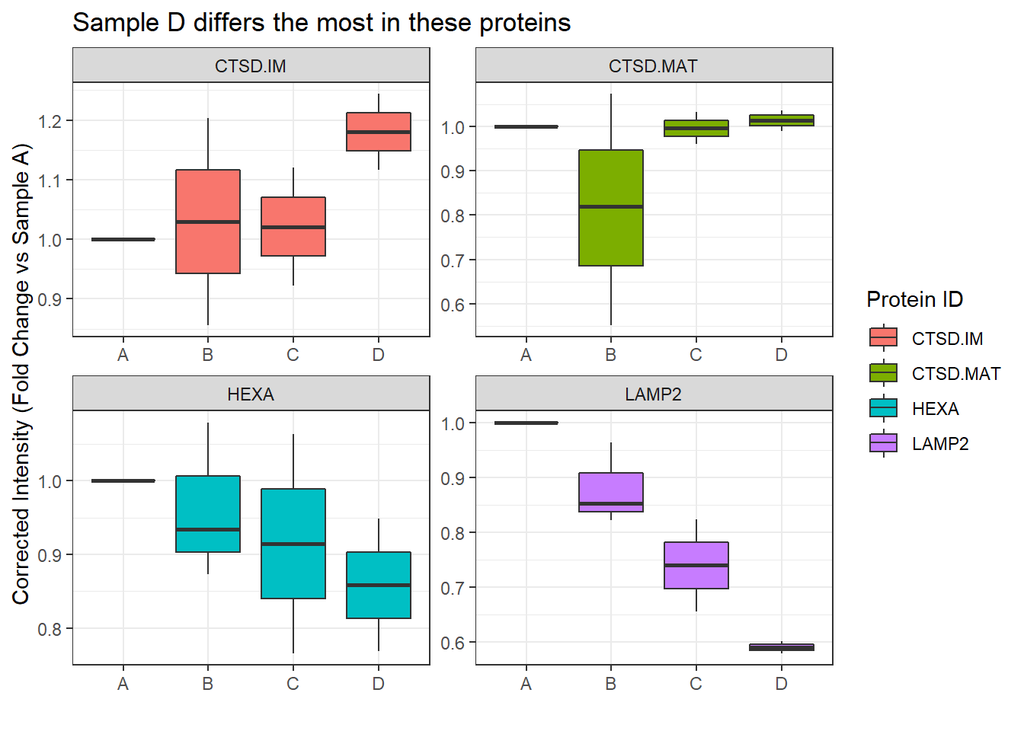

```r
# Let's take the fold change by each date

hek_combined_clean %>%
  group_by(date, protein) %>%
  mutate(fold_change = value_corrected/first(value_corrected)) %>%
  ggplot(aes(x = sampleid, y = fold_change, fill = str_to_upper(protein)))+
  geom_boxplot()+
  facet_wrap(~ str_to_upper(protein),
             scales = "free")+
  xlab("")+
  ylab("Corrected Intensity (Fold Change vs Sample A)")+
  ggtitle("Sample D differs the most in these proteins")+
  labs(fill = "Protein ID")+
  theme_bw()
```

### Enzyme Contaminants

Now let’s say I have some protein samples that I think are contaminated with active enzyme. So, I have taken some enzyme assay data that I’ve taken at a few time points

I want to plot the change in values for the different samples over time.

```r
ts <- read_csv("../data/part1/enzyme_contaminants_ts.csv")
head(ts)
```

```
## # A tibble: 6 x 5
##   sampleid     t0   t30   t60   t90
##   <chr>     <dbl> <dbl> <dbl> <dbl>
## 1 enzyme     1010  1335  2194  2901
## 2 enzyme     1073  1170  1827  2354
## 3 protein_a  1155  1065  1867  2855
## 4 protein_a   950   938  1666  2578
## 5 protein_b  1089   794   880   905
## 6 protein_b  1045   758   875   884
```

There is not really much to clean from this data. However, we see that the data is in a “wide” or a “spread out” format. While it was more convenient to collect the data like this, I ideally want to pull the time variable (which is currently spread horizontally) to be vertical This may be referred to as “melting” the data frame (in Python). In R, this is called “pivoting” the data Essentially, you take this output and pivot it from wide to long format. It is better understood when seen in action

```r
ts_cleaned <- ts %>%
  pivot_longer(
    contains("t"),
    names_to = "time_point",
    values_to = "value",
    names_prefix = "t"
  ) %>%
  mutate(time_point = as.numeric(time_point))
```

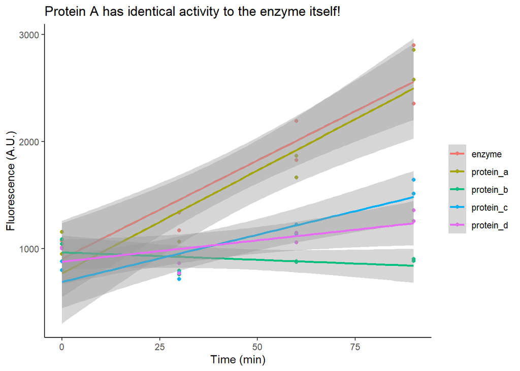

```r
ts_cleaned %>%
  ggplot(aes(x = time_point, y = value, color = sampleid))+
  geom_point()+
  geom_smooth(method = "lm",
              formula = "y ~ x",
              se = TRUE)+
  xlab("Time (min)")+
  ylab("Fluorescence (A.U.)")+
  labs(color = "")+
  ggtitle("Protein A has identical activity to the enzyme itself!")+
  theme_classic()
```

### DRC

Let’s say I have some enzyme assay data that I want to use a DRC for

```r
drc <- read_csv("../data/part1/drc.csv")
drc
```

```
## # A tibble: 8 x 5
##   well_id sample_id sample  dose values
##   <chr>       <dbl> <chr>  <dbl>  <dbl>
## 1 C2              1 enzyme   15   0.053
## 2 D2              2 enzyme   15   0.088
## 3 E2              3 enzyme   30   0.132
## 4 F2              4 enzyme   30   0.193
## 5 G2              5 enzyme   60   0.269
## 6 B3              6 enzyme   60   0.2
## 7 C3              7 enzyme  103.  0.256
## 8 D3              8 enzyme  103.  0.273
```

It looks like this data is already tidy and ready to be plotted! How do we plot a nonlinear line?

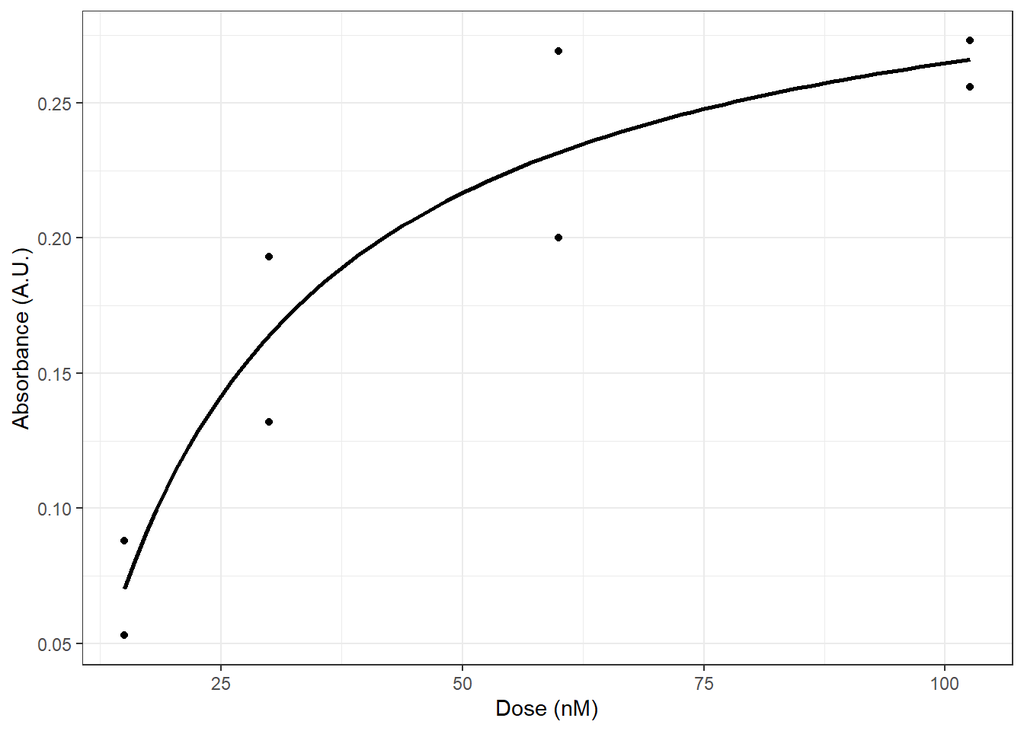

```r
drc %>%
  ggplot(aes(dose, values))+
  geom_point()+
  geom_smooth(method = "nls",
              formula = "y ~ ylo + x*(yhi-ylo)/(k+x)", #You do have to know what formula will fit your data! This is the formula for a dose response curve with a hill slope of 1
              method.args = list( # When using nonlinear methods, you'll need to give 'start' arguments to tell the optimization algorthim where to start looking for the data. Feel free to play around with these if the model fails to converge
                start = c(yhi = 0.25, ylo = 0, k = 1)),
              se = FALSE, #Make sure you set standard error (se) to be false. Unfortunately, this calculation can prevent proper plotting if the points do not fit the line very well.
              color = "black")+
  theme_bw()+
  xlab("Dose (nM)") + ylab("Absorbance (A.U.)")
```

Note: I highly recommend looking at the Graphpad Prism website if you do not know exactly which model best fits your data. They have great resources for considering different models, and you can pull the equations from them.

https://www.graphpad.com/guides/prism/7/curve-fitting/reg_entering_data_for_nonlinear_re.htm

## Citations

Choleris, E., Thomas, A. W., Kavaliers, M., & Prato, F. S. (2001). A detailed ethological analysis of the mouse open field test: effects of diazepam, chlordiazepoxide and an extremely low frequency pulsed magnetic field. Neuroscience and biobehavioral reviews, 25(3), 235–260. https://doi.org/10.1016/s0149-7634(01)00011-2

https://vita.had.co.nz/papers/layered-grammar.html